# Quiballo_Assignment_5

##

OnMart Superstore

**Author: Atef Bader** **Created: 8/19/2021**  
Date: 15 Sept 2021  
Edited by: Dr. Dill  
- Assigned points to each question  
- Clarified each question  
- Added bonus questions

### Deliverables: - Submit on Canvas two files with the format of **Lastname_Assignment_5**: 1. Your IPYNB script that has your source code and output for the requirements listed below 2. Your HTML document that has your source code and output for the requirements listed below

## High Level Description: The OnMart superstore is an online retailer that has a business model similar to Amazon, Walmart, and Target. The online superstore has several departments that are selling products in different categories: Electronics, Clothing, Grocery, Furniture, Sports, etc.

The following is a sample of the delivery zip codes, warehouses, distribution centers, cities, and state:

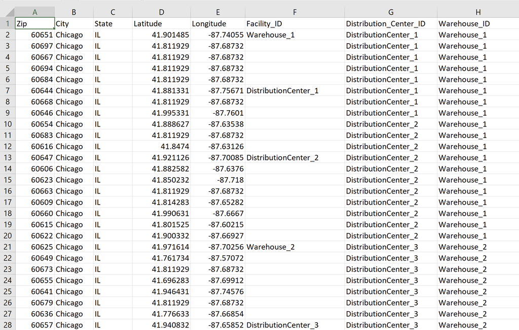

# Departments and Products

OnMart has several departments that are selling products in different categories. The following is a sample of these departments and the different product categories they sell:

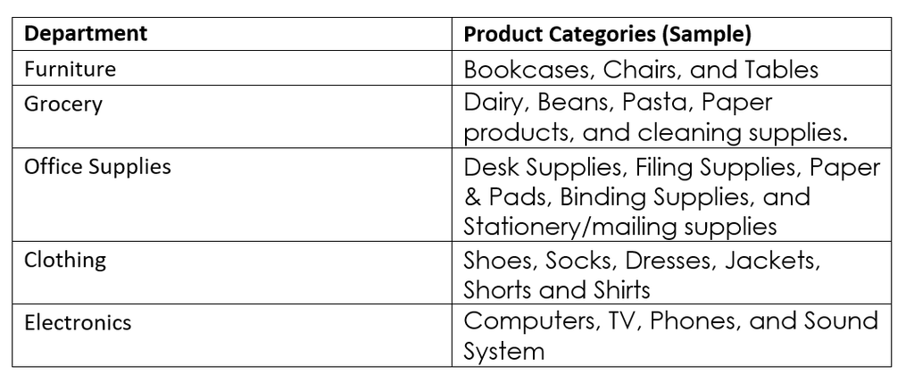

# Customers and Purchases

Customers place their orders online and the order might have products from the different categories in the different departments. For every order there will be a unique order number generated. When the customers place the order online, the customer will enter home address, delivery address, and shipping class.

The customer is provided with the following capabilities:

- Purchase items.
- Return purchased items.
- Review and rate purchased items.
- Some customers are connected with friends in a Social Network and can share product description of purchased items with friends in the social network.

**Connection instructions**

- Connect to NU VPN
- Connect to DSCC Postgres Server via psycog2 connection string (provided in code below)
- Connect to **onmart** database (provided in code below)
- Use the two tables: **transactions_log** and **logistics_supply_chain_network**

```python
import pandas as pd
import datetime
from datetime import datetime, date, timedelta
import time
import numpy as np
import sys
!{sys.executable} -m pip install plotly
import plotly
import seaborn as sns
import matplotlib
import matplotlib.pyplot as plt
import matplotlib.dates as mdates
import plotly.express as px
import psycopg2
import csv

import sys
!{sys.executable} -m pip install area
from area import area

from psycopg2.extensions import ISOLATION_LEVEL_AUTOCOMMIT
from IPython.display import display
```

```python
# allow muliple output in one cell window
from IPython.core.interactiveshell import InteractiveShell
InteractiveShell.ast_node_interactivity = "all"
```

### Check versions:

```python
from platform import python_version
print('python version installed     :', python_version(),'    ,needed: 3.7.7 or higher')
print('plotly version installed     :', plotly.__version__,'   ,needed: 4.14.3 or higher')
print('matplotlib version installed :', matplotlib.__version__,'    ,needed: 3.2.2 or higher')
print('numpy version installed      :', np.__version__,'    ,needed: 1.19.5 or higher')
```

```
python version installed     : 3.8.5     ,needed: 3.7.7 or higher
plotly version installed     : 5.3.1    ,needed: 4.14.3 or higher
matplotlib version installed : 3.3.3     ,needed: 3.2.2 or higher
numpy version installed      : 1.19.4     ,needed: 1.19.5 or higher
```

```python
# Connect to onmart database on Postgres

db_connection = psycopg2.connect(host='129.105.248.26',dbname="onmart", user="kjq978")

cursor = db_connection.cursor()
```

```python
# Get the column names for table transactions_log

cursor.execute("SELECT column_name \
                FROM INFORMATION_SCHEMA.COLUMNS \
                WHERE table_name = 'transactions_log';")

rows=cursor.fetchall()

rows
```

```
[('customerid',),
 ('firstname',),
 ('lastname',),
 ('creditcardnumber',),
 ('orderid',),
 ('purchasedate',),
 ('expecteddeliverydate',),
 ('actualdeliverydate',),
 ('productid',),
 ('department',),
 ('category',),
 ('itempurchased',),
 ('quantity',),
 ('price',),
 ('shippingcost',),
 ('discount',),
 ('sales',),
 ('profit',),
 ('deliveryzipcode',),
 ('homezipcode',),
 ('segment',),
 ('orderpriority',),
 ('orderreturned',),
 ('rating',),
 ('reviewid',),
 ('friends',),
 ('sharedwith',)]
```

```python
# Load the table transactions_log into a dataframe:
#dfTrans = pd.read_sql_query("select * from transactions_log", db_connection)
#dfTrans.head()
#dfTrans.info()
```

```python
# create a dataframe for transaction_log - note the limit to 5000 records
query = '''SELECT *
            FROM transactions_log
            LIMIT 5000;'''

cursor.execute(query)
data = cursor.fetchall()

colnames = [desc[0] for desc in cursor.description]
#create dataframe with column headers
customers = pd.DataFrame(data, columns = colnames)
customers.info()
customers.head()
```

```
<class 'pandas.core.frame.DataFrame'>
RangeIndex: 5000 entries, 0 to 4999
Data columns (total 27 columns):
 #   Column                Non-Null Count  Dtype
---  ------                --------------  -----
 0   customerid            5000 non-null   object
 1   firstname             5000 non-null   object
 2   lastname              5000 non-null   object
 3   creditcardnumber      5000 non-null   object
 4   orderid               5000 non-null   object
 5   purchasedate          5000 non-null   object
 6   expecteddeliverydate  5000 non-null   object
 7   actualdeliverydate    5000 non-null   object
 8   productid             5000 non-null   object
 9   department            5000 non-null   object
```

[output cut: 19 more lines]

|  | customerid | firstname | lastname | creditcardnumber | orderid | purchasedate | expecteddeliverydate | actualdeliverydate | productid | department | ... | profit | deliveryzipcode | homezipcode | segment | orderpriority | orderreturned | rating | reviewid | friends | sharedwith |
| --- | --- | --- | --- | --- | --- | --- | --- | --- | --- | --- | --- | --- | --- | --- | --- | --- | --- | --- | --- | --- | --- |
| 0 | 539-52-6371 | Dejon | Wehner | xxxx-xxxx-xxxx-0075 | effbec6e-966a-48f1-9569-a16d85949d8d | 2019-02-15 | 2019-02-19 | 2019-02-23 | GRO-SN-9382-624 | Grocery | ... | 2.1126 | 10167 | 10111 | Home Office | Critical | No | 4 |  | 705-35-1974 |  |
| 1 | 280-93-0722 | Myrtie | Tillman | xxxx-xxxx-xxxx-6037 | e8582ce0-70d4-44fa-a009-ae6c74ab084a | 2018-09-13 | 2018-09-17 | 2018-09-21 | GRO-NU-2312-936 | Grocery | ... | 0.4086 | 10167 | 75265 | Home Office | low | No | 5 | 82ce0-70d4 | 611-28-1471;218-92-0690;786-82-5936 | 218-92-0690;786-82-5936 |
| 2 | 775-86-2896 | Efren | Fisher | xxxx-xxxx-xxxx-0369 | a80dc622-107f-48e9-801a-8550c4948b19 | 2018-07-25 | 2018-07-29 | 2018-08-02 | OFF-AP-4065-596 | Office Supplies | ... | 226.9140 | 10167 | 60681 | Home Office | low | No | -1 |  | 168-48-2512;507-66-2046;855-63-5933 | 855-63-5933 |
| 3 | 854-06-2341 | Kenneth | Wehner | xxxx-xxxx-xxxx-3254 | c7255a4b-bb50-4dfb-9fd2-ffa9676ff8b6 | 2019-07-05 | 2019-07-09 | 2019-07-13 | SPO-GO-5887-738 | Sports | ... | 198.7974 | 10167 | 33266 | Home Office | Critical | Yes | 4 | 55a4b-bb50 | 004-42-4255;523-36-8224;831-11-9305;557-42-1178 | 831-11-9305 |
| 4 | 575-76-9030 | Ana | Senger | xxxx-xxxx-xxxx-6690 | a5d62c31-17ad-435d-950e-3e51d6ea288c | 2019-07-26 | 2019-07-30 | 2019-07-30 | SPO-GO-7784-650 | Sports | ... | 93.5376 | 10167 | 60652 | Corporate | Critical | No | 3 |  |  |  |

5 rows × 27 columns

```python
# check out customer

cursor.execute("SELECT * \
                FROM transactions_log \
                Where customerid = '004-81-0268';")

rows = cursor.fetchall()

rows
```

```
[('004-81-0268',
  'Lydia',
  'Turner',
  'xxxx-xxxx-xxxx-5873',
  '5d585c1e-1df4-4eb2-8bc5-aba8dc173087',
  datetime.date(2019, 10, 8),
  datetime.date(2019, 10, 12),
  datetime.date(2019, 10, 12),
  'ELE-CO-2076-686',
  'Electronics',
  'Copiers',
  'HP Multipurpose Laser Scanner',
  2,
  540.26,
  24.2,
  20.51,
  1084.21,
  119.2631,
  '30309',
  '30309',
  'Consumer',
  'High',
  'No',
  5,
  '',
  '',
  '')]
```

```python
# Get the column names for table logistics_supply_chain_network

cursor.execute("SELECT column_name \
                FROM INFORMATION_SCHEMA.COLUMNS \
                WHERE table_name = 'logistics_supply_chain_network';")

rows=cursor.fetchall()

rows
```

```
[('zipcode',),
 ('city',),
 ('state',),
 ('latitude',),
 ('longitude',),
 ('facility_id',),
 ('distribution_center_id',),
 ('warehouse_id',),
 ('where_is',)]
```

```python
# create dataframe for the supply chain network table
query = '''SELECT *
            FROM logistics_supply_chain_network;'''

cursor.execute(query)
data = cursor.fetchall()

colnames = [desc[0] for desc in cursor.description]
#create dataframe with column headers
centers = pd.DataFrame(data, columns = colnames).drop_duplicates()
centers.info()
centers.head()
```

```
<class 'pandas.core.frame.DataFrame'>
Int64Index: 785 entries, 0 to 784
Data columns (total 9 columns):
 #   Column                  Non-Null Count  Dtype
---  ------                  --------------  -----
 0   zipcode                 785 non-null    object
 1   city                    785 non-null    object
 2   state                   785 non-null    object
 3   latitude                785 non-null    float64
 4   longitude               785 non-null    float64
 5   facility_id             785 non-null    object
 6   distribution_center_id  785 non-null    object
 7   warehouse_id            785 non-null    object
 8   where_is                0 non-null      object
dtypes: float64(2), object(7)
memory usage: 61.3+ KB
```

|  | zipcode | city | state | latitude | longitude | facility_id | distribution_center_id | warehouse_id | where_is |
| --- | --- | --- | --- | --- | --- | --- | --- | --- | --- |
| 0 | 60651 | Chicago | IL | 41.901485 | -87.74055 | Warehouse_1 | DistributionCenter_1 | Warehouse_1 | None |
| 1 | 60697 | Chicago | IL | 41.811929 | -87.68732 |  | DistributionCenter_1 | Warehouse_1 | None |
| 2 | 60667 | Chicago | IL | 41.811929 | -87.68732 |  | DistributionCenter_1 | Warehouse_1 | None |
| 3 | 60694 | Chicago | IL | 41.811929 | -87.68732 |  | DistributionCenter_1 | Warehouse_1 | None |
| 4 | 60684 | Chicago | IL | 41.811929 | -87.68732 |  | DistributionCenter_1 | Warehouse_1 | None |

```python
# check out zips
centers['zipcode'].nunique()
```

```
785
```

```python
# check out locations
centers['facility_id'].nunique()
centers['distribution_center_id'].nunique()
centers['warehouse_id'].nunique()
```

```
119
```

```
97
```

```
22
```

```python
# what states are there?
centers['state'].value_counts()
```

```
NY    166
TX    123
GA    111
CA    100
FL     96
IL     85
MA     54
TN     44
VA      1
IA      1
NJ      1
MI      1
NC      1
PA      1
Name: state, dtype: int64
```

### Complete all requirements listed below - Write your code in the cell below every requirement

```python
# Uncomment and run this code when your transactions get "stuck"
db_connection.rollback()
```

### Requirement 1 (5 points): - To see the delivery zip code with the most returns, count the total number of order returns per Delivery Zip Code. Show the top five zip codes with their count. **( Use SQL - Postgres )**

```python
query = '''SELECT deliveryzipcode, COUNT(orderreturned) as total_order_returns
            FROM transactions_log
            WHERE orderreturned='Yes'
            GROUP BY deliveryzipcode
            ORDER BY total_order_returns DESC;'''

cursor.execute(query)
data = cursor.fetchall()

#create dataframe with column headers
colnames = [desc[0] for desc in cursor.description]
pd.DataFrame(data, columns = colnames).drop_duplicates().head(5)
```

|  | deliveryzipcode | total_order_returns |
| --- | --- | --- |
| 0 | 75202 | 1421 |
| 1 | 60660 | 1411 |
| 2 | 75210 | 1395 |
| 3 | 75218 | 1386 |
| 4 | 60649 | 1386 |

### Requirement 2 (5 points): - Which product categories had the most returns? We want to know the number of returns by the category and the delivery zip code. Count the total number of orders for every product category in every Delivery Zip Code. The output should show the category, the zip code and the count; show the top 10. **( Use SQL - Postgres )**

```python
query = '''SELECT category, deliveryzipcode, COUNT(orderreturned) as total_order_returns
            FROM transactions_log
            WHERE orderreturned='Yes'
            GROUP BY category, deliveryzipcode
            ORDER BY total_order_returns DESC;'''

cursor.execute(query)
data = cursor.fetchall()

#create dataframe with column headers
colnames = [desc[0] for desc in cursor.description]
pd.DataFrame(data, columns = colnames).drop_duplicates().head(10)
```

|  | category | deliveryzipcode | total_order_returns |
| --- | --- | --- | --- |
| 0 | Shorts | 60643 | 146 |
| 1 | Shorts | 60614 | 143 |
| 2 | Shorts | 75202 | 141 |
| 3 | TShirt | 75212 | 136 |
| 4 | TShirt | 60660 | 136 |
| 5 | TShirt | 60646 | 133 |
| 6 | Shorts | 75210 | 131 |
| 7 | TShirt | 60626 | 130 |
| 8 | TShirt | 60678 | 130 |
| 9 | TShirt | 60624 | 129 |

### Requirement 3 (5 points): Calculate the total sales per Delivery Zip Code; Use the **sales** column for your total sales value. Sort by total sales with the highest amount showing on top. **( Use SQL - Postgres )**

```python
query = '''SELECT deliveryzipcode, SUM(sales) as total_sales
            FROM transactions_log
            GROUP BY deliveryzipcode
            ORDER BY total_sales DESC;'''

cursor.execute(query)
data = cursor.fetchall()

#create dataframe with column headers
colnames = [desc[0] for desc in cursor.description]
pd.DataFrame(data, columns = colnames).drop_duplicates().head(10)
```

|  | deliveryzipcode | total_sales |
| --- | --- | --- |
| 0 | 60636 | 6723517.19 |
| 1 | 75225 | 6663814.60 |
| 2 | 60679 | 6634994.33 |
| 3 | 75210 | 6629017.59 |
| 4 | 60646 | 6620039.21 |
| 5 | 75214 | 6569905.55 |
| 6 | 75224 | 6562457.31 |
| 7 | 60673 | 6536017.53 |
| 8 | 75223 | 6523289.58 |
| 9 | 60615 | 6509460.70 |

|  | deliveryzipcode | category | total_sales |
| --- | --- | --- | --- |
| 0 | 75210 | Hunting & Fishing | 1916583.36 |
| 1 | 60636 | Hunting & Fishing | 1805624.49 |
| 2 | 60626 | Hunting & Fishing | 1804465.11 |
| 3 | 60615 | Hunting & Fishing | 1799572.30 |
| 4 | 60625 | Hunting & Fishing | 1796514.49 |

[output not shown]

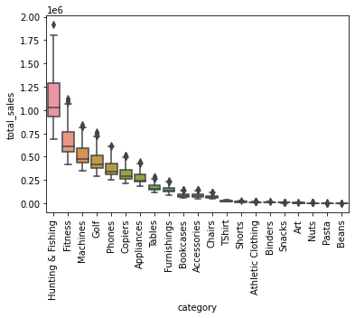

```python
query = '''SELECT deliveryzipcode, category, SUM(sales) as total_sales
            FROM transactions_log
            GROUP BY deliveryzipcode, category
            ORDER BY total_sales DESC;'''

cursor.execute(query)
data = cursor.fetchall()

#create dataframe with column headers
colnames = [desc[0] for desc in cursor.description]
df = pd.DataFrame(data, columns = colnames)
df.head()

############################################################
sns.boxplot( y=df["total_sales"], x=df['category'] );
plt.xticks(rotation = 90)
```

### Requirement 5 (15 points): - Calculate the total number of orders per product category per Home Zip Code per purchase month. Sort by home zip code, cateogry and month and show the first 12 records. **( Use Python - SQL - Postgres )**  
You can use either Python or SQL to create the month field. If you want to try SQL, here is one of many sources of info: https://www.postgresqltutorial.com/postgresql-extract/

```python
query = '''SELECT category, homezipcode, EXTRACT(MONTH from purchasedate) as month, COUNT(*) as total_orders
            FROM transactions_log
            GROUP BY homezipcode, category, month
            ORDER BY homezipcode, category, month;'''

cursor.execute(query)
data = cursor.fetchall()

#create dataframe with column headers
colnames = [desc[0] for desc in cursor.description]
pd.DataFrame(data, columns = colnames).drop_duplicates().head(12)
```

|  | category | homezipcode | month | total_orders |
| --- | --- | --- | --- | --- |
| 0 | Accessories | 10001 | 1.0 | 23 |
| 1 | Accessories | 10001 | 2.0 | 31 |
| 2 | Accessories | 10001 | 3.0 | 8 |
| 3 | Accessories | 10001 | 4.0 | 10 |
| 4 | Accessories | 10001 | 5.0 | 8 |
| 5 | Accessories | 10001 | 6.0 | 22 |
| 6 | Accessories | 10001 | 7.0 | 15 |
| 7 | Accessories | 10001 | 8.0 | 11 |
| 8 | Accessories | 10001 | 9.0 | 14 |
| 9 | Accessories | 10001 | 10.0 | 17 |
| 10 | Accessories | 10001 | 11.0 | 34 |
| 11 | Accessories | 10001 | 12.0 | 13 |

### Requirement 6 (15 points): - Use Seaborn (FacetGrid and scatterplot) to create six scatter plots, one for each zipcode in the list of zipcodes [60623, 60663, 60609, 60660, 60615, 60622]. - Each zip code should appear in its own chart. - Plot the daily sales for these categories: Athletic Clothing, Fitness, Golf, Hunting & Fishing, Shorts - The colors in the plots should represent the categories. - **( Use Python - SQL - Postgres )**  
Reference: https://seaborn.pydata.org/generated/seaborn.FacetGrid.html

|  | deliveryzipcode | category | purchasedate | daily_sales |
| --- | --- | --- | --- | --- |
| 0 | 60609 | Athletic Clothing | 2018-01-14 | 48.28 |
| 1 | 60609 | Athletic Clothing | 2018-01-15 | 164.21 |
| 2 | 60609 | Athletic Clothing | 2018-01-23 | 47.65 |
| 3 | 60609 | Athletic Clothing | 2018-01-27 | 243.64 |
| 4 | 60609 | Athletic Clothing | 2018-01-28 | 99.90 |

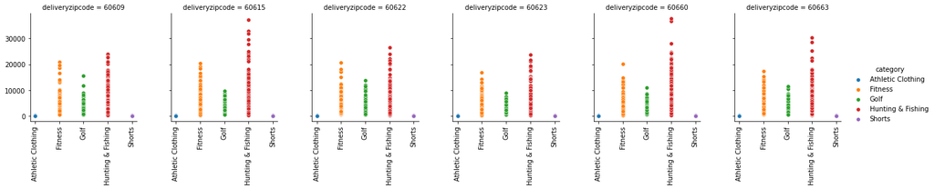

```python
query = '''SELECT deliveryzipcode, category, purchasedate, SUM(sales) as daily_sales
            FROM transactions_log
            WHERE (deliveryzipcode='60623' OR deliveryzipcode='60663' OR deliveryzipcode='60609' OR
                    deliveryzipcode='60660' OR deliveryzipcode='60615' OR deliveryzipcode='60622')
            AND (category='Athletic Clothing' OR category='Fitness' OR category='Golf' OR
                 category='Hunting & Fishing' OR category='Shorts')
            GROUP BY deliveryzipcode, category, purchasedate;'''

cursor.execute(query)
data = cursor.fetchall()

#create dataframe with column headers
colnames = [desc[0] for desc in cursor.description]
df = pd.DataFrame(data, columns = colnames)
df.head()

############################################################
g = sns.FacetGrid(df, col="deliveryzipcode", hue="category")
g.map_dataframe(sns.scatterplot, x="category", y="daily_sales")
for axes in g.axes.flat:
    _ = axes.set_xticklabels(axes.get_xticklabels(), rotation=90)
g.add_legend()
```

### Requirement 7 (5 points): - List the top 10 distribution centers that have **highest** number of delayed deliveries? Show the distribution center ID, the city, the center's zip and the number of delayed deliveries. **( Use Python - SQL - Postgres )**

```python
db_connection.rollback()
query = '''SELECT l.distribution_center_id, l.city, l.zipcode, SUM(t.delayed) as delayed_deliveries
            FROM (SELECT *,
            CASE
                WHEN actualdeliverydate <= expecteddeliverydate THEN 0
                WHEN actualdeliverydate > expecteddeliverydate THEN 1
            END AS delayed
            FROM transactions_log) as t
            LEFT JOIN logistics_supply_chain_network as l
            ON t.deliveryzipcode = l.zipcode
            WHERE t.delayed = 1
            GROUP BY l.distribution_center_id, l.city, l.zipcode, t.delayed
            ORDER BY delayed_deliveries DESC;'''

cursor.execute(query)
data = cursor.fetchall()

#create dataframe with column headers
colnames = [desc[0] for desc in cursor.description]
df = pd.DataFrame(data, columns = colnames)
df.iloc[1:11]
```

|  | distribution_center_id | city | zipcode | delayed_deliveries |
| --- | --- | --- | --- | --- |
| 1 | DistributionCenter_2 | Chicago | 60660 | 5352 |
| 2 | DistributionCenter_75 | Dallas | 75225 | 5323 |
| 3 | DistributionCenter_5 | Chicago | 60632 | 5320 |
| 4 | DistributionCenter_4 | Chicago | 60664 | 5318 |
| 5 | DistributionCenter_7 | Chicago | 60630 | 5299 |
| 6 | DistributionCenter_8 | Chicago | 60678 | 5265 |
| 7 | DistributionCenter_66 | Dallas | 75214 | 5264 |
| 8 | DistributionCenter_6 | Chicago | 60620 | 5262 |
| 9 | DistributionCenter_2 | Chicago | 60683 | 5258 |
| 10 | DistributionCenter_6 | Chicago | 60634 | 5256 |

### Requirement 8 (15 points): - Find the most **influential product reviewer** for every product. - Note: the **influential product reviewer** is the customer who rated the product either 5 or 1, wrote a review for the product, has the highest number of friends, and shared it with the highest number of friends. **( Use Python - SQL - Postgres )** - In the following example customer c3 is the most influential reviewer (list is sorted decending by the **count** of sharedwith and friends)

**Example:**

1. c3 : sharedwith=5, friends=10

2. c1 : sharedwith=4, friends=15

3. c2 : sharedwith=4, friends=10

4. c5 : sharedwith=3, friends=12

5. c4 : sharedwith=3, friends=10

### Hints for Requirement 8

1. Select all your data
2. Parse the friends field to get a count and store in your dataframe
3. Parse the sharedwith field to get a count and store in your dataframe
4. Sort output by sharewith count and friends count

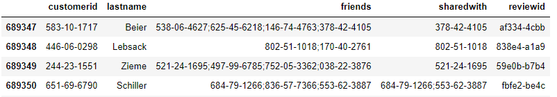

```python
db_connection.rollback()
query = '''SELECT productid, customerid, rating, lastname, friends, sharedwith, reviewid
            FROM transactions_log
            WHERE (rating=1 OR rating=5)
            AND reviewid <> '' ;'''

cursor.execute(query)
data = cursor.fetchall()

#create dataframe with column headers
colnames = [desc[0] for desc in cursor.description]
df = pd.DataFrame(data, columns = colnames)
df['friends_count'] = df['friends'].str.count(";")+1
df.loc[df['friends'] == '', 'friends_count'] = 0
df['sharedwith_count'] = df['sharedwith'].str.count(";")+1
df.loc[df['sharedwith'] == '', 'sharedwith_count'] = 0
df = df.sort_values(['friends_count', 'sharedwith_count'], ascending=False)
df = df.drop_duplicates(subset='productid', keep='first') #1,379,692
df
```

|  | productid | customerid | rating | lastname | friends | sharedwith | reviewid | friends_count | sharedwith_count |
| --- | --- | --- | --- | --- | --- | --- | --- | --- | --- |
| 20 | ELE-AC-0501-357 | 797-42-4887 | 1 | Kirlin | 834-24-9521;038-82-1414;444-45-7521;613-67-8240 | 834-24-9521;038-82-1414;444-45-7521;613-67-8240 | 7b19c-9ad3 | 4 | 4 |
| 115 | ELE-MA-9012-860 | 017-35-3210 | 5 | Brown | 863-85-8396;172-48-4372;196-13-5745;448-81-1185 | 863-85-8396;172-48-4372;196-13-5745;448-81-1185 | eb00f-4ce1 | 4 | 4 |
| 133 | CLO-TS-4063-681 | 164-71-3107 | 1 | Beahan | 536-99-0424;885-96-0731;055-97-0821;660-24-1120 | 536-99-0424;885-96-0731;055-97-0821;660-24-1120 | 75401-1665 | 4 | 4 |
| 258 | GRO-PA-3404-438 | 810-64-0970 | 1 | Abernathy | 306-91-3175;255-45-9375;554-82-1098;583-71-1772 | 306-91-3175;255-45-9375;554-82-1098;583-71-1772 | b6392-17ae | 4 | 4 |
| 271 | GRO-PA-4148-488 | 716-02-2811 | 1 | Monahan | 258-92-4931;506-06-1511;715-47-1727;320-96-4036 | 258-92-4931;506-06-1511;715-47-1727;320-96-4036 | a3bd7-fe99 | 4 | 4 |
| ... | ... | ... | ... | ... | ... | ... | ... | ... | ... |
| 689338 | OFF-AR-3315-488 | 462-20-5376 | 1 | Fritsch |  |  | 9dbbe-5605 | 0 | 0 |
| 689340 | ELE-MA-1104-320 | 032-54-9522 | 1 | Lebsack |  |  | 0c03c-e0c1 | 0 | 0 |
| 689342 | ELE-MA-8834-285 | 485-72-2352 | 5 | Rice |  |  | f7e65-f581 | 0 | 0 |
| 689343 | OFF-AR-5292-759 | 375-74-7646 | 5 | Block |  |  | 0c3e9-4778 | 0 | 0 |
| 689346 | CLO-SH-9665-357 | 676-09-5047 | 1 | McKenzie |  |  | c5cba-f35f | 0 | 0 |

687897 rows × 9 columns

```python
len(pd.unique(df['productid']))
#there are 687897 unique product ids
```

```
687897
```

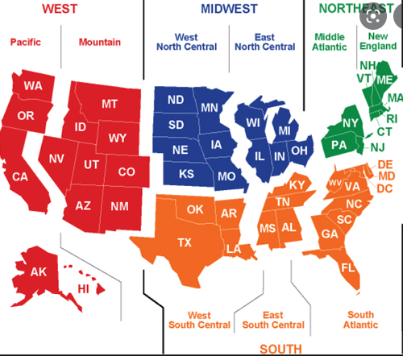

### Bonus 2 (10 points): - To better plan for hiring hourly temporary workers on the peak-day of the week, OnMart has requested to find the busiest day of the week (Monday, Tuesday, Wednesday, Thursday, Friday, Saturday or Sunday) that has the highest average for the number of order deliveries in every delivery zip code. Use the actual delivery date to determine the day of the week. **( Use Python - SQL - Postgres )**

```python
db_connection.rollback()
query = '''SELECT deliveryzipcode, COUNT(*) as total_orders, EXTRACT(dow from purchasedate) as day_of_week
            FROM transactions_log
            GROUP BY deliveryzipcode, day_of_week
            ORDER BY total_orders DESC;'''

cursor.execute(query)
data = cursor.fetchall()

#create dataframe with column headers
colnames = [desc[0] for desc in cursor.description]
df = pd.DataFrame(data, columns = colnames).drop_duplicates()

df.loc[df['day_of_week'] == 1, 'day_of_week'] = "Monday"
df.loc[df['day_of_week'] == 2, 'day_of_week'] = "Tuesday"
df.loc[df['day_of_week'] == 3, 'day_of_week'] = "Wednesday"
df.loc[df['day_of_week'] == 4, 'day_of_week'] = "Thursday"
df.loc[df['day_of_week'] == 5, 'day_of_week'] = "Friday"
df.loc[df['day_of_week'] == 6, 'day_of_week'] = "Saturday"
df.loc[df['day_of_week'] == 7, 'day_of_week'] = "Sunday"
df.loc[df['day_of_week'] == 0, 'day_of_week'] = "Sunday"

df.drop_duplicates(subset='deliveryzipcode', keep='first')
```

|  | deliveryzipcode | total_orders | day_of_week |
| --- | --- | --- | --- |
| 0 | 75204 | 1203 | Saturday |
| 1 | 60655 | 1200 | Thursday |
| 2 | 75203 | 1196 | Thursday |
| 3 | 60633 | 1195 | Thursday |
| 4 | 60631 | 1164 | Thursday |
| ... | ... | ... | ... |
| 3127 | 90087 | 593 | Friday |
| 3149 | 2208 | 592 | Thursday |
| 3299 | 33180 | 587 | Thursday |
| 3393 | 90052 | 584 | Friday |
| 3524 | 90046 | 580 | Thursday |

785 rows × 3 columns